# Reproducible Research: Peer Assessment 1

triharder

Started August 5, 2015 due August 16, 2015

### Loading and preprocessing the data

```r
#1 Load the data
raw <- read.csv("activity.csv")
#2 Process/transform
proc <- na.omit(raw)
```

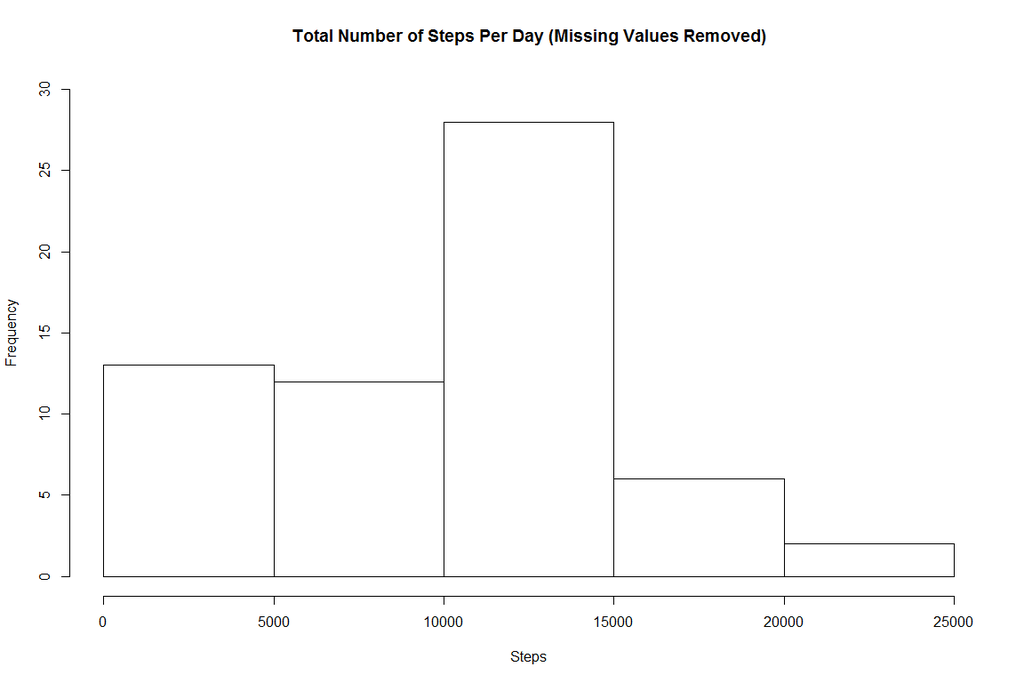

```r
#1 calculate total steps per day
sum_steps = sapply(split(proc$steps, proc$date), sum)

#2 histogram of total steps per day
hist(sum_steps, main="Total Number of Steps Per Day (Missing Values Removed)", xlab = "Steps", ylab = "Frequency", ylim=range(0:30))
```

The mean and median number of steps taken per day are calculated as follows:

```r
#3 mean and median total number of steps taken per day
avg_spd <- mean(sum_steps)
med_spd <- median(sum_steps)
```

Respectively, the mean and median number of steps taken per day are **9354 and 10395**.

### What is the average daily activity pattern?

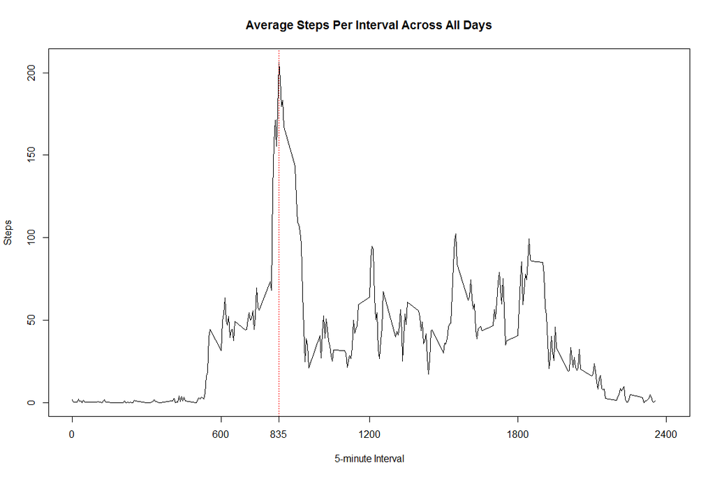

```r
#1 Time series plot of 5-minute interval (x-axis) and the average number of steps taken, averaged across all days (y-axis)
avg_spi <- tapply(proc$steps, proc$interval, mean)
plot(unique(proc$interval),avg_spi,type="l",main="Average Steps Per Interval Across All Days",xlab="5-minute Interval",ylab="Steps",xlim = c(0,2400),xaxt="n")
axis(side=1,at=c(0,600,1200,1800,2400))
#2 5-minute interval with max steps across all days
avg_spi <- as.data.frame.table(avg_spi)
colnames(avg_spi)<-c("int","avgSPI")
max_int <- avg_spi$int[which.max(avg_spi$avgSPI)]
abline(v=835,lty=3,col="red")
axis(side=1,at=835)
```

### Imputing missing values

There are **2304** missing values in the raw data, determined by the following expression:

```r
#1 Calculate total missing values
nrow(raw)-nrow(proc)
```

Implementing the strategy to fill missing values based on the average for relative interval, both the process and new dataset can be observed below:

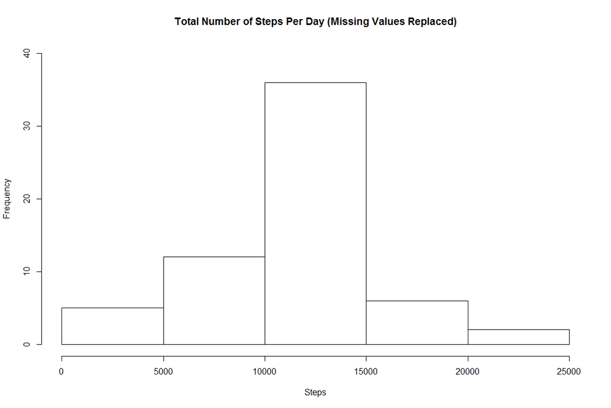

```r
#2 Process to fill in missing values
##  Fill NA values in 'steps' with the value for respective interval averaged across all days.

#3 New dataset replacing missing values
fill <- raw
fill$steps[is.na(fill$steps)]<-avg_spi$avgSPI

#4 Histogram
sum_steps_fill = sapply(split(fill$steps, fill$date), sum,na.rm=T)
hist(sum_steps_fill, main="Total Number of Steps Per Day (Missing Values Replaced)", xlab = "Steps", ylab = "Frequency", ylim=range(0:40))
```

```r
avg_spd_fill <- mean(sum_steps_fill)
med_spd_fill <- median(sum_steps_fill)
```

After imputing the data, there are **0** **NAs**.

The mean and median number of steps taken per day are **10766 and 10766**, respectively.

The impact of imputing missing data on the estimates of the total daily number of steps reduces variablity. Overall, there is no added value and less clarity.

### Are there differences in activity patterns between weekdays and weekends?

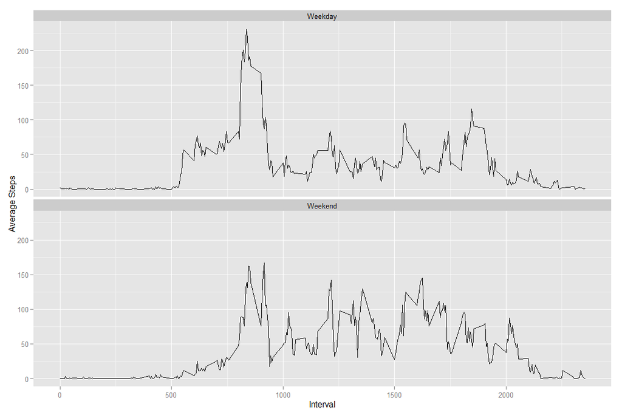

```r
#1 Create factor variable with "weekday" and "weekend" levels
#use weekdays() on filled data
library(dplyr)
library(lubridate)
fill <- mutate(fill,Weekday = wday(ymd(fill$date),label=T))
fill <- mutate(fill,Weekday = factor(ifelse(Weekday %in% c("Sat","Sun"),"Weekend","Weekday")))

#2 Panel plot with time series averaged per level (Weekday or Weekend)
library(ggplot2)
avg_spw <- aggregate(steps ~ interval + Weekday,fill,mean)
ggplot(avg_spw,aes(interval,steps)) + geom_line() + labs(x="Interval",y="Average Steps") + facet_wrap(~Weekday, nrow=2, ncol =1)
```